# Rapport Final Tunisair

## Methodologie de travail CRISP-DM:

La méthode CRISP se décompose en 6 étapes allant de la compréhension du probleme metier au deploiement et la mise en production. Elle reste aujourd’hui la seule méthode utilisable efficacement pour tous les projets Data Science.

## Comprehension du Metier:

Malgré son expérience dans le domaine aérien ,puisqu’elle été fondé en 1948, Tunisair n’arriva pas d’être parmi les compagnies les plus populaires dans le monde. Tunisair opère sur 4 continent du globe mais avec un intervalle limité.

Les limitations de son budget est un point cruciale constaté d’aprés L’évolution lente de la compagnie. Elle admet une flotte de 28 avions avec une moyenne d’âge plus que 16 ans . C’est pour cela la compagnie vise à moderniser la flotte pour qu’elle puisse répondre mieux au exigences internationales.

Pour exécuter notre étude nous devons répondre aux questionx suivantes :

- Est-ce que la flotte actuelle de Tunisair répond aux exigences internationales ?
- Peut-on affirmer que les modèles disponibles dans la compagnie tunisienne joignent les normes standards favorisant la concurrence sur l’échelle régionale et/ou internationale ?
- Comment peut-on catégoriser une telle panoplie de modèles d’avions ?
- Quel est le profil typique des avions dans le monde ?

D’où nos objectifs data science seront la segmentation des avions de Tunisair et du monde pour distinguer leurs caractéristiques .

Et enfin trouver une solution ou une équation pour aider les administrateurs de la compagnie à l’évoluer, dont leurs buts principaux seront d’assurer les conditions les plus favorables aux visiteurs de notre pays, suivre les progrès scientifiques et technologiques et s’adapter avec l’augmentation exponentielle du trafic aérien

## Compréhension des données:

Nous disposons 3 fichiers .csv :

-Le fichier EconomyClassShort.csv qui a été fourni regroupe 434 avions du monde entier appartenant à des differentes compagnies aeriennes, et enumère 8 de leurs caractéristiques.

-Le fichier FirstClassShort.csv qui a été fourni regroupe 355 avions du monde entier appartenant à des differentes compagnies aeriennes, et enumère 9 de leurs caractéristiques.

-Le fichier ModelsDataSet.csv qui regroupe 54 modéles d’avions du monde entier,s et enumere 37 de leurs caracteristiques.

-Le fichier Fleet-Data.csv qui regroupe 11 variables, et enumere 1579 observations

## Modélisation:

Exploration du fichier EconomyClassShort.csv contenant tous les modeles d’avion :

```r
##Importation du fichier
all <- read.csv("C:/Users/Nidhal/Downloads/EconomyClassShort.csv")
#(all[c(3,4,5,6,7,8)])
allData<-na.omit(all[c(3,4,6,7)])
```

Puisque les variables n’ont pas tous la meme unite, on a choisi de faire un centrage et reduction:

```r
allScaled<-scale(allData)
```

Pour determiner le nombre optimale de clusters, on a utilisé la methode elbow:

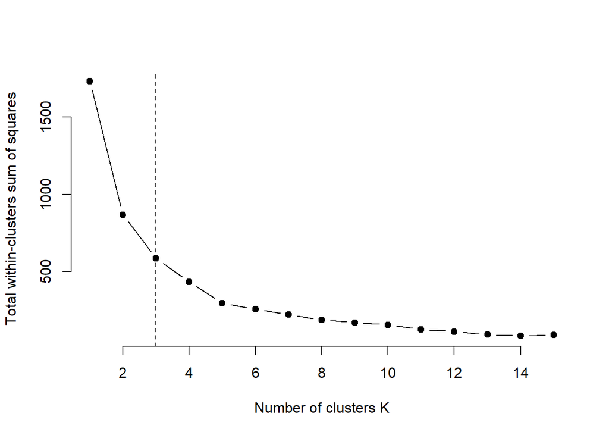

```r
##elbow method
k.max <- 15 # Maximal number of clusters
data <- allScaled
wss <- sapply(1:k.max,
              function(k){kmeans(data, k, nstart=10 )$tot.withinss})

plot(1:k.max, wss,
     type="b", pch = 19, frame = FALSE,
     xlab="Number of clusters K",
     ylab="Total within-clusters sum of squares")
abline(v = 3, lty =2)
```

Segmentation avec la methode Kmeans en 3 clusters:

```r
kmeanstestall<-kmeans(allScaled,3)
library("ggfortify")
```

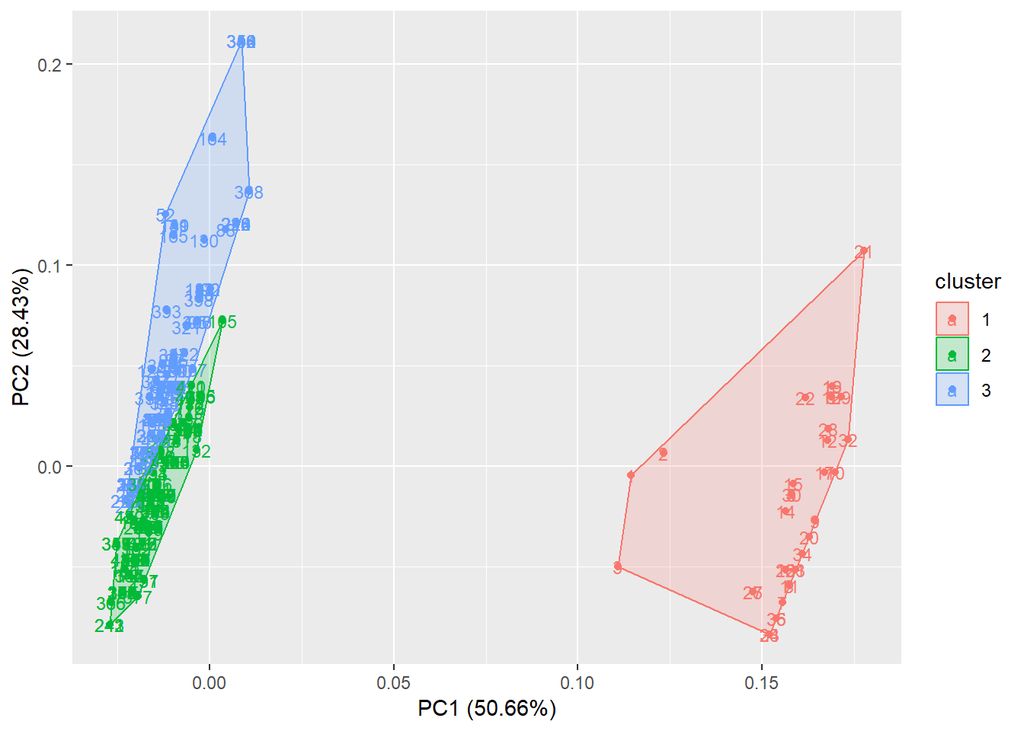

```r
autoplot(kmeanstestall, data = allScaled,
         label = TRUE, label.size = 3, frame = TRUE)
```

Calculer les moyennes pour chaque cluster:

```r
finalRAll<-aggregate(allData,by=list(kmeanstestall$cluster),mean)
(finalRAll)
```

```
##   Group.1 Seat.Pitch Seat.Width Laptop.Power Power.Type
## 1       1   32.15278   17.53611     1.916667          1
## 2       2   31.11600   17.10782     0.000000          0
## 3       3   31.53378   18.18574     0.000000          0
```

```r
clust <- names(sort(table(kmeanstestall$cluster)))

summary(all[kmeanstestall$clust==clust[1],1:2])
```

```
##                 Airline               Aircraft.with.seatmap
##  Delta              :7   Airbus A320neo (320)    : 3
##  WOW air            :6   Boeing 737 MAX 8 (7M8)  : 3
##  United             :5   Airbus A220-300         : 2
##  Alaska Airlines    :4   Airbus A319 (319)       : 2
##  LOT Polish Airlines:3   Airbus A320 (320)       : 2
##  Aeroflot           :2   Airbus A320 (320/32K) V2: 2
##  (Other)            :9   (Other)                 :22
```

```r
summary(all[kmeanstestall$clust==clust[2],1:2])
```

```
##               Airline             Aircraft.with.seatmap
##  Alitalia         : 10   Airbus A320 (320)   :17
##  Frontier         : 10   Airbus A319 (319)   :10
##  Germanwings      :  8   Airbus A321 (321)   : 9
##  Air France       :  7   Airbus A319 (319) V1: 6
##  Japan Airlines   :  6   Airbus A319 (319) V2: 6
##  American Airlines:  5   Airbus A320 (320) V1: 6
##  (Other)          :102   (Other)             :94
```

```r
summary(all[kmeanstestall$clust==clust[3],1:2])
```

```
##               Airline              Aircraft.with.seatmap
##  United           : 26   Boeing 737-800 (738) : 17
##  American Airlines: 24   Airbus A320 (320)    : 12
##  Delta            : 13   Bombardier Q400 (DH4): 10
##  KLM              :  9   Airbus A319 (319)    :  7
##  Air France       :  8   ATR 72-500 (AT7)     :  6
##  Iberia           :  8   Boeing 737-700 (737) :  6
##  (Other)          :162   (Other)              :192
```

### Tunisair à l’echelle international/regional

```r
clust <- names(sort(table(kmeanstestall$cluster)))
x<-all[all[,"Airline"]=="Tunis Air",]
summary(x[kmeanstestall$clust==clust[1],1:2])
```

```
##                   Airline            Aircraft.with.seatmap
##  Tunis Air            : 4   Airbus A319 (319) V1: 1
##  Aegean Airlines      : 0   Airbus A319 (319) V2: 1
##  Aer Lingus           : 0   Airbus A320 (320)   : 1
##  Aeroflot             : 0   Boeing 737-600 (736): 1
##  Aerolineas Argentinas: 0   Aerospatiale ATR-42 : 0
##  (Other)              : 0   (Other)             : 0
##  NA's                 :32   NA's                :32
```

```r
summary(x[kmeanstestall$clust==clust[2],1:2])
```

```
##                   Airline                            Aircraft.with.seatmap
##  Aegean Airlines      :  0   Aerospatiale ATR-42                :  0
##  Aer Lingus           :  0   Aerospatiale/Alenia 42-500 (AT5)   :  0
##  Aeroflot             :  0   Aerospatiale/Alenia 72-500 (AT7) V1:  0
##  Aerolineas Argentinas:  0   Aerospatiale/Alenia 72-500 (AT7) V2:  0
##  Aeromexico           :  0   Aerospatiale/Alenia 72-600 (AT7)   :  0
##  (Other)              :  0   (Other)                            :  0
##  NA's                 :148   NA's                               :148
```

```r
summary(x[kmeanstestall$clust==clust[3],1:2])
```

```
##                   Airline                            Aircraft.with.seatmap
##  Aegean Airlines      :  0   Aerospatiale ATR-42                :  0
##  Aer Lingus           :  0   Aerospatiale/Alenia 42-500 (AT5)   :  0
##  Aeroflot             :  0   Aerospatiale/Alenia 72-500 (AT7) V1:  0
##  Aerolineas Argentinas:  0   Aerospatiale/Alenia 72-500 (AT7) V2:  0
##  Aeromexico           :  0   Aerospatiale/Alenia 72-600 (AT7)   :  0
##  (Other)              :  0   (Other)                            :  0
##  NA's                 :250   NA's                               :250
```

```r
clust <- names(sort(table(kmeanstestall$cluster)))
#Royal Air
x1<-all[all[,"Airline"]=="Royal Air Maroc",]
summary(x1[kmeanstestall$clust==clust[1],1:2])
```

```
##                   Airline                           Aircraft.with.seatmap
##  Royal Air Maroc      : 2   ATR 72-600 (AT7)                   : 1
##  Aegean Airlines      : 0   Embraer E-190 (E90)                : 1
##  Aer Lingus           : 0   Aerospatiale ATR-42                : 0
##  Aeroflot             : 0   Aerospatiale/Alenia 42-500 (AT5)   : 0
##  Aerolineas Argentinas: 0   Aerospatiale/Alenia 72-500 (AT7) V1: 0
##  (Other)              : 0   (Other)                            : 0
##  NA's                 :34   NA's                               :34
```

```r
summary(x1[kmeanstestall$clust==clust[2],1:2])
```

```
##                   Airline                            Aircraft.with.seatmap
##  Aegean Airlines      :  0   Aerospatiale ATR-42                :  0
##  Aer Lingus           :  0   Aerospatiale/Alenia 42-500 (AT5)   :  0
##  Aeroflot             :  0   Aerospatiale/Alenia 72-500 (AT7) V1:  0
##  Aerolineas Argentinas:  0   Aerospatiale/Alenia 72-500 (AT7) V2:  0
##  Aeromexico           :  0   Aerospatiale/Alenia 72-600 (AT7)   :  0
##  (Other)              :  0   (Other)                            :  0
##  NA's                 :148   NA's                               :148
```

```r
summary(x1[kmeanstestall$clust==clust[3],1:2])
```

```
##                   Airline                            Aircraft.with.seatmap
##  Aegean Airlines      :  0   Aerospatiale ATR-42                :  0
##  Aer Lingus           :  0   Aerospatiale/Alenia 42-500 (AT5)   :  0
##  Aeroflot             :  0   Aerospatiale/Alenia 72-500 (AT7) V1:  0
##  Aerolineas Argentinas:  0   Aerospatiale/Alenia 72-500 (AT7) V2:  0
##  Aeromexico           :  0   Aerospatiale/Alenia 72-600 (AT7)   :  0
##  (Other)              :  0   (Other)                            :  0
##  NA's                 :250   NA's                               :250
```

```r
clust <- names(sort(table(kmeanstestall$cluster)))
#Ethiopian Airlines
x2<-all[all[,"Airline"]=="Ethiopian Airlines",]
summary(x2[kmeanstestall$clust==clust[1],1:2])
```

```
##                   Airline                           Aircraft.with.seatmap
##  Ethiopian Airlines   : 2   Bombardier Q400 (DH4) V1           : 1
##  Aegean Airlines      : 0   Bombardier Q400 (DH4) V2           : 1
##  Aer Lingus           : 0   Aerospatiale ATR-42                : 0
##  Aeroflot             : 0   Aerospatiale/Alenia 42-500 (AT5)   : 0
##  Aerolineas Argentinas: 0   Aerospatiale/Alenia 72-500 (AT7) V1: 0
##  (Other)              : 0   (Other)                            : 0
##  NA's                 :34   NA's                               :34
```

```r
summary(x2[kmeanstestall$clust==clust[2],1:2])
```

```
##                   Airline                            Aircraft.with.seatmap
##  Aegean Airlines      :  0   Aerospatiale ATR-42                :  0
##  Aer Lingus           :  0   Aerospatiale/Alenia 42-500 (AT5)   :  0
##  Aeroflot             :  0   Aerospatiale/Alenia 72-500 (AT7) V1:  0
##  Aerolineas Argentinas:  0   Aerospatiale/Alenia 72-500 (AT7) V2:  0
##  Aeromexico           :  0   Aerospatiale/Alenia 72-600 (AT7)   :  0
##  (Other)              :  0   (Other)                            :  0
##  NA's                 :148   NA's                               :148
```

```r
summary(x2[kmeanstestall$clust==clust[3],1:2])
```

```
##                   Airline                            Aircraft.with.seatmap
##  Aegean Airlines      :  0   Aerospatiale ATR-42                :  0
##  Aer Lingus           :  0   Aerospatiale/Alenia 42-500 (AT5)   :  0
##  Aeroflot             :  0   Aerospatiale/Alenia 72-500 (AT7) V1:  0
##  Aerolineas Argentinas:  0   Aerospatiale/Alenia 72-500 (AT7) V2:  0
##  Aeromexico           :  0   Aerospatiale/Alenia 72-600 (AT7)   :  0
##  (Other)              :  0   (Other)                            :  0
##  NA's                 :250   NA's                               :250
```

```r
clust <- names(sort(table(kmeanstestall$cluster)))
#Delta
x3<-all[all[,"Airline"]=="Delta",]
summary(x3[kmeanstestall$cluster==1,1:2])
```

```
##                   Airline                   Aircraft.with.seatmap
##  Delta                :25   Airbus A320 (320/32K) V2   : 2
##  Aegean Airlines      : 0   Airbus A320 (320/32R) V1   : 2
##  Aer Lingus           : 0   Boeing 717-200 (717)       : 2
##  Aeroflot             : 0   Boeing 757-200 (75G)       : 2
##  Aerolineas Argentinas: 0   Bombardier CRJ-700 (CR7) V1: 2
##  (Other)              : 0   (Other)                    :15
##  NA's                 :11   NA's                       :11
```

```r
summary(x3[kmeanstestall$cluster==2,1:2])
```

```
##                   Airline                            Aircraft.with.seatmap
##  Aegean Airlines      :  0   Aerospatiale ATR-42                :  0
##  Aer Lingus           :  0   Aerospatiale/Alenia 42-500 (AT5)   :  0
##  Aeroflot             :  0   Aerospatiale/Alenia 72-500 (AT7) V1:  0
##  Aerolineas Argentinas:  0   Aerospatiale/Alenia 72-500 (AT7) V2:  0
##  Aeromexico           :  0   Aerospatiale/Alenia 72-600 (AT7)   :  0
##  (Other)              :  0   (Other)                            :  0
##  NA's                 :250   NA's                               :250
```

```r
summary(x3[kmeanstestall$cluster==3,1:2])
```

```
##                   Airline                            Aircraft.with.seatmap
##  Aegean Airlines      :  0   Aerospatiale ATR-42                :  0
##  Aer Lingus           :  0   Aerospatiale/Alenia 42-500 (AT5)   :  0
##  Aeroflot             :  0   Aerospatiale/Alenia 72-500 (AT7) V1:  0
##  Aerolineas Argentinas:  0   Aerospatiale/Alenia 72-500 (AT7) V2:  0
##  Aeromexico           :  0   Aerospatiale/Alenia 72-600 (AT7)   :  0
##  (Other)              :  0   (Other)                            :  0
##  NA's                 :148   NA's                               :148
```

### First Class Classification

Exploration du fichier FirstClassShort.csv contenant tous les modeles d’avion :

```r
##Importation du fichier
all <- read.csv("C:/Users/Nidhal/Downloads/FirstClassShort.csv")
#(all[c(3,4,5,6,7,8)])
allData<-na.omit(all[c(3,4,6,7)])
View(allData)
```

Puisque les variables n’ont pas tous la même unité, on a choisi de faire un centrage et réduction:

```r
allScaled<-scale(allData)
```

Pour determiner le nombre optimale de clusters, on a utilise la methode elbow:

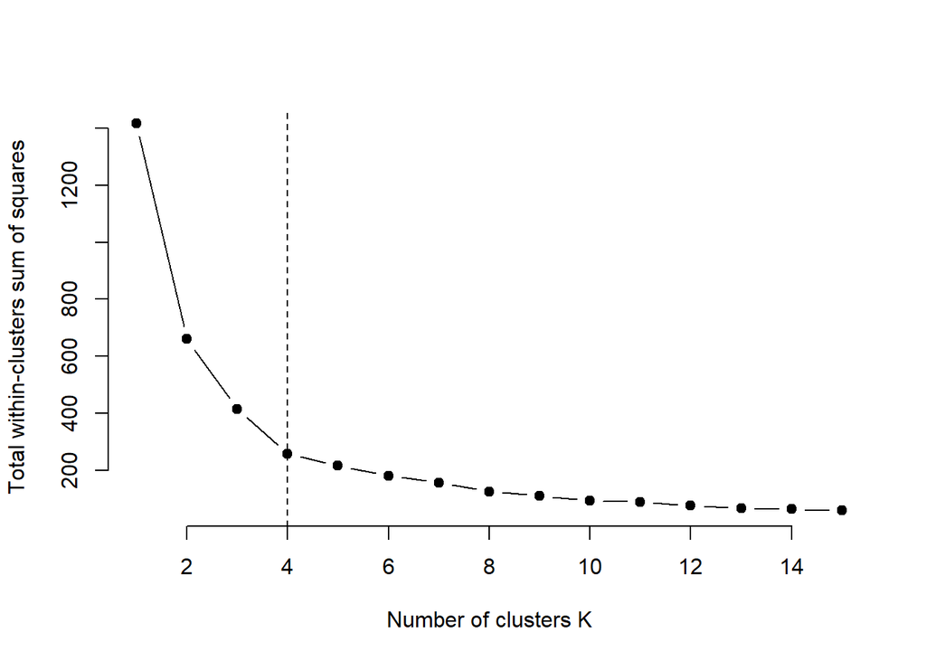

```r
##elbow method
k.max <- 15 # Maximal number of clusters
data <- allScaled
wss <- sapply(1:k.max,
              function(k){kmeans(data, k, nstart=10 )$tot.withinss})

plot(1:k.max, wss,
     type="b", pch = 19, frame = FALSE,
     xlab="Number of clusters K",
     ylab="Total within-clusters sum of squares")
abline(v = 4, lty =2)
```

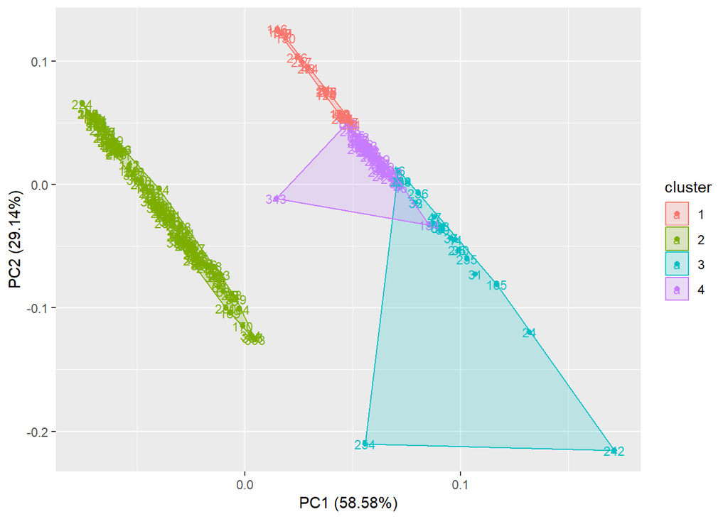

```r
kmeanstestall<-kmeans(allScaled,4)
library("ggfortify")
autoplot(kmeanstestall, data = allScaled,
         label = TRUE, label.size = 3, frame = TRUE)
```

Calculer les moyennes pour chaque cluster:

```r
finalRAll2<-aggregate(allData,by=list(kmeanstestall$cluster),mean)
(finalRAll2)
```

```
##   Group.1 Seat.Pitch Seat.Width Laptop.Power Power.Type
## 1       1   36.35897   18.92564     2.000000  1.0000000
## 2       2   36.73571   19.57281     0.000000  0.0000000
## 3       3   59.29167   20.81667     1.916667  0.9583333
## 4       4   39.39024   20.87317     1.975610  1.0000000
```

Pour les avions ayant un First class, on a touvé 4 clusters:

```r
clust <- names(sort(table(kmeanstestall$cluster)))

summary(all[kmeanstestall$clust==clust[1],1:2])
```

```
##               Airline                  Aircraft.with.seatmap
##  Virgin America   : 3   Airbus A321 (321) Transcon: 2
##  American Airlines: 2   Airbus A321 (32B) Transcon: 2
##  ANA              : 2   Airbus A330-300 (333) V1  : 2
##  JetBlue          : 2   Boeing 737-800 (738) V2   : 2
##  Korean Air       : 2   Airbus A318 (318)         : 1
##  Qatar Airways    : 2   Airbus A319-133LR (319)   : 1
##  (Other)          :11   (Other)                   :14
```

```r
summary(all[kmeanstestall$clust==clust[2],1:2])
```

```
##            Airline              Aircraft.with.seatmap
##  China Eastern : 7   Airbus A319 (319)     : 4
##  Delta         : 5   Airbus A320 (320)     : 4
##  Avianca       : 4   Boeing 737-700 (737)  : 3
##  Japan Airlines: 4   Boeing 737-800 (738)  : 3
##  Air France    : 3   Airbus A321 (321)     : 2
##  KLM           : 3   Boeing 737 MAX 8 (7M8): 2
##  (Other)       :13   (Other)               :21
```

```r
summary(all[kmeanstestall$clust==clust[3],1:2])
```

```
##               Airline               Aircraft.with.seatmap
##  United           :15   Airbus A320 (320) V1   : 5
##  Air Canada       : 9   Boeing 737-800 (738)   : 5
##  Delta            : 8   Boeing 737-800 (738) V1: 5
##  Aeroflot         : 6   Boeing 737-800 (738) V2: 5
##  American Airlines: 6   Boeing 737 MAX 8 (7M8) : 5
##  Alaska Airlines  : 4   Airbus A319 (319)      : 4
##  (Other)          :34   (Other)                :53
```

```r
clust <- names(sort(table(kmeanstestall$cluster)))
x<-all[all[,"Airline"]=="Tunis Air",]
summary(x[kmeanstestall$clust==clust[1],1:2])
```

```
##                   Airline                        Aircraft.with.seatmap
##  Aegean Airlines      : 0   Aerospatiale/Alenia 72-600 (AT7): 0
##  Aeroflot             : 0   Airbus A318 (318)               : 0
##  Aerolineas Argentinas: 0   Airbus A319-100 (319)           : 0
##  Aeromexico           : 0   Airbus A319-133LR (319)         : 0
##  Air Austral          : 0   Airbus A319 (319)               : 0
##  (Other)              : 0   (Other)                         : 0
##  NA's                 :24   NA's                            :24
```

```r
summary(x[kmeanstestall$clust==clust[2],1:2])
```

```
##                   Airline                        Aircraft.with.seatmap
##  Aegean Airlines      : 0   Aerospatiale/Alenia 72-600 (AT7): 0
##  Aeroflot             : 0   Airbus A318 (318)               : 0
##  Aerolineas Argentinas: 0   Airbus A319-100 (319)           : 0
##  Aeromexico           : 0   Airbus A319-133LR (319)         : 0
##  Air Austral          : 0   Airbus A319 (319)               : 0
##  (Other)              : 0   (Other)                         : 0
##  NA's                 :39   NA's                            :39
```

```r
summary(x[kmeanstestall$clust==clust[3],1:2])
```

```
##                   Airline                        Aircraft.with.seatmap
##  Tunis Air            : 2   Airbus A319 (319) V1            : 1
##  Aegean Airlines      : 0   Airbus A320 (320)               : 1
##  Aeroflot             : 0   Aerospatiale/Alenia 72-600 (AT7): 0
##  Aerolineas Argentinas: 0   Airbus A318 (318)               : 0
##  Aeromexico           : 0   Airbus A319-100 (319)           : 0
##  (Other)              : 0   (Other)                         : 0
##  NA's                 :80   NA's                            :80
```

```r
summary(x[kmeanstestall$clust==clust[4],1:2])
```

```
##                   Airline                         Aircraft.with.seatmap
##  Aegean Airlines      :  0   Aerospatiale/Alenia 72-600 (AT7):  0
##  Aeroflot             :  0   Airbus A318 (318)               :  0
##  Aerolineas Argentinas:  0   Airbus A319-100 (319)           :  0
##  Aeromexico           :  0   Airbus A319-133LR (319)         :  0
##  Air Austral          :  0   Airbus A319 (319)               :  0
##  (Other)              :  0   (Other)                         :  0
##  NA's                 :210   NA's                            :210
```

```r
clust <- names(sort(table(kmeanstestall$cluster)))
x<-all[all[,"Airline"]=="Delta",]
summary(x[kmeanstestall$clust==clust[1],1:2])
```

```
##                   Airline                        Aircraft.with.seatmap
##  Delta                : 1   Airbus A320 (320/32R) V1        : 1
##  Aegean Airlines      : 0   Aerospatiale/Alenia 72-600 (AT7): 0
##  Aeroflot             : 0   Airbus A318 (318)               : 0
##  Aerolineas Argentinas: 0   Airbus A319-100 (319)           : 0
##  Aeromexico           : 0   Airbus A319-133LR (319)         : 0
##  (Other)              : 0   (Other)                         : 0
##  NA's                 :23   NA's                            :23
```

```r
summary(x[kmeanstestall$clust==clust[2],1:2])
```

```
##                   Airline                        Aircraft.with.seatmap
##  Delta                : 4   Boeing 757-200 (757)            : 1
##  Aegean Airlines      : 0   Bombardier CRJ-700 (CR7) V3     : 1
##  Aeroflot             : 0   McDonnell Douglas MD-88 (M88)   : 1
##  Aerolineas Argentinas: 0   McDonnell Douglas MD-90 (M90)   : 1
##  Aeromexico           : 0   Aerospatiale/Alenia 72-600 (AT7): 0
##  (Other)              : 0   (Other)                         : 0
##  NA's                 :35   NA's                            :35
```

```r
summary(x[kmeanstestall$clust==clust[3],1:2])
```

```
##                   Airline                Aircraft.with.seatmap
##  Delta                :17   Airbus A319 (319) V2    : 1
##  Aegean Airlines      : 0   Airbus A320 (320/32K) V2: 1
##  Aeroflot             : 0   Airbus A321 (321)       : 1
##  Aerolineas Argentinas: 0   Boeing 717-200 (717)    : 1
##  Aeromexico           : 0   Boeing 737-700 (73W)    : 1
##  (Other)              : 0   (Other)                 :12
##  NA's                 :65   NA's                    :65
```

```r
clust <- names(sort(table(kmeanstestall$cluster)))
x<-all[all[,"Airline"]=="Ethiopian Airlines",]
summary(x[kmeanstestall$clust==clust[1],1:2])
```

```
##                   Airline                        Aircraft.with.seatmap
##  Aegean Airlines      : 0   Aerospatiale/Alenia 72-600 (AT7): 0
##  Aeroflot             : 0   Airbus A318 (318)               : 0
##  Aerolineas Argentinas: 0   Airbus A319-100 (319)           : 0
##  Aeromexico           : 0   Airbus A319-133LR (319)         : 0
##  Air Austral          : 0   Airbus A319 (319)               : 0
##  (Other)              : 0   (Other)                         : 0
##  NA's                 :24   NA's                            :24
```

```r
summary(x[kmeanstestall$clust==clust[2],1:2])
```

```
##                   Airline                        Aircraft.with.seatmap
##  Aegean Airlines      : 0   Aerospatiale/Alenia 72-600 (AT7): 0
##  Aeroflot             : 0   Airbus A318 (318)               : 0
##  Aerolineas Argentinas: 0   Airbus A319-100 (319)           : 0
##  Aeromexico           : 0   Airbus A319-133LR (319)         : 0
##  Air Austral          : 0   Airbus A319 (319)               : 0
##  (Other)              : 0   (Other)                         : 0
##  NA's                 :39   NA's                            :39
```

```r
summary(x[kmeanstestall$clust==clust[3],1:2])
```

```
##                   Airline                        Aircraft.with.seatmap
##  Ethiopian Airlines   : 3   Boeing 737-700 (737)            : 1
##  Aegean Airlines      : 0   Boeing 737-800 (738)            : 1
##  Aeroflot             : 0   Bombardier Q400 (DH4) V1        : 1
##  Aerolineas Argentinas: 0   Aerospatiale/Alenia 72-600 (AT7): 0
##  Aeromexico           : 0   Airbus A318 (318)               : 0
##  (Other)              : 0   (Other)                         : 0
##  NA's                 :79   NA's                            :79
```

```r
summary(x[kmeanstestall$clust==clust[4],1:2])
```

```
##                   Airline                         Aircraft.with.seatmap
##  Aegean Airlines      :  0   Aerospatiale/Alenia 72-600 (AT7):  0
##  Aeroflot             :  0   Airbus A318 (318)               :  0
##  Aerolineas Argentinas:  0   Airbus A319-100 (319)           :  0
##  Aeromexico           :  0   Airbus A319-133LR (319)         :  0
##  Air Austral          :  0   Airbus A319 (319)               :  0
##  (Other)              :  0   (Other)                         :  0
##  NA's                 :210   NA's                            :210
```

## Evaluation:

# Panoplie des modéles d’avions et modéle typique

## Modélisation

Récupération des données a partir du fichier ModelsDataSet.csv contenant tous les modéles des avions :

```r
data <- read.csv(file="C:/Users/Nidhal/Downloads/ModelsDataSet.csv",header=T,sep=";",dec=",")

data3 <- data.frame(data$Type..Model,data$Aspect.Ratio.Wing,data$Speed..kt.,data$Price,data$Max..seats..single.class.)
data4 <- na.omit(data3)
View(data4)
```

Sélection des variables à utiliser (consommation,vitesse,prix,capacité) et élimination des deux variables qualitatives (type et nom du modéle):

```r
data5 <- data4
data5$data.Type..Model<-NULL
View(data5)
data5$data.Price <- as.numeric(gsub(",", ".", data5$data.Price))
data5$data.Aspect.Ratio.Wing <- as.numeric(gsub(",", ".", data5$data.Aspect.Ratio.Wing))
```

Utilisation de la méthode “elbow” pour déterminer le meuilleur nombre de groupe :

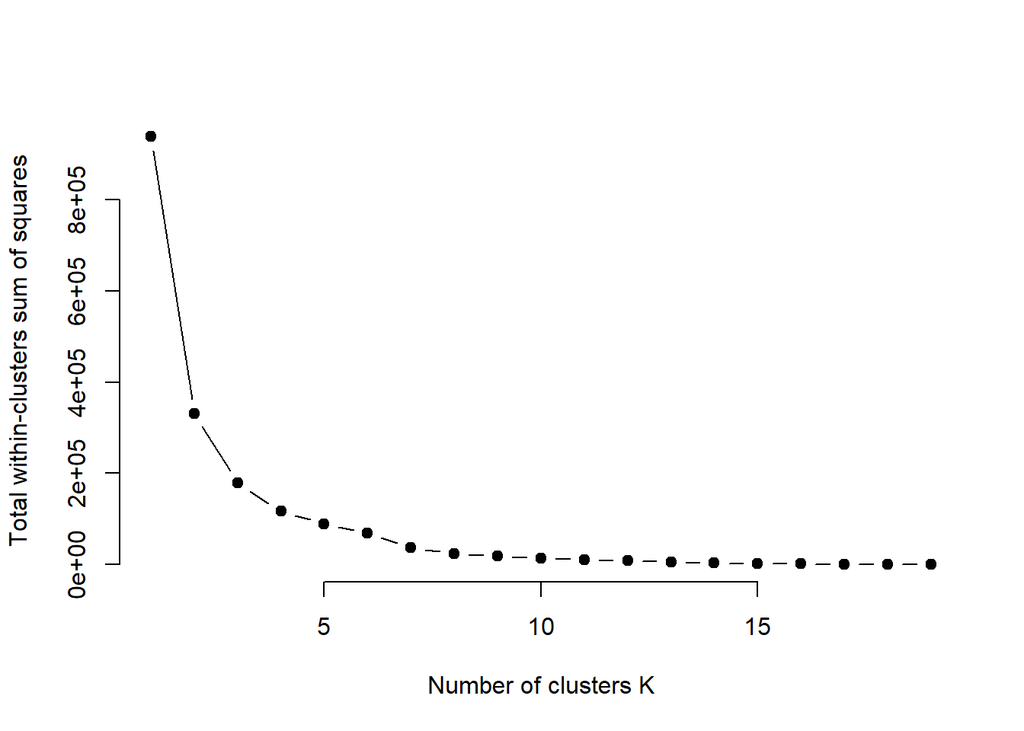

```r
k.max <-19
wss <- sapply(1:k.max,function(k){kmeans(data5, k, nstart=10 )$tot.withinss})
plot(1:k.max, wss,type="b", pch = 19, frame = FALSE,xlab="Number of clusters K",ylab="Total within-clusters sum of squares")
```

```r
segs<- scale(data5,center= TRUE,scale=TRUE)
segs <- kmeans(data5,4)
clust <- names(sort(table(segs$cluster)))
summary(data4)
```

```
##   data.Type..Model data.Aspect.Ratio.Wing data.Speed..kt.   data.Price
##  777-200ER: 1      Min.   :6.606          Min.   :410.0   101    : 1
##  A300-600R: 1      1st Qu.:7.779          1st Qu.:487.0   105    : 1
##  A310-300 : 1      Median :7.988          Median :490.5   114,9  : 1
##  A319-100 : 1      Mean   :8.249          Mean   :491.6   160,2  : 1
##  A320-200 : 1      3rd Qu.:9.197          3rd Qu.:505.5   182,8  : 1
##  A321-100 : 1      Max.   :9.395          Max.   :530.0   19,6   : 1
##  (Other)  :14                                             (Other):14
##  data.Max..seats..single.class.
##  Min.   : 50.0
##  1st Qu.:176.8
##  Median :247.0
##  Mean   :295.4
##  3rd Qu.:368.8
##  Max.   :850.0
##
```

```r
data4[segs$cluster==clust[1],]
```

```
##    data.Type..Model data.Aspect.Ratio.Wing data.Speed..kt. data.Price
## 11         A380-800                  7.794             507      445,6
## 19         B747-400                  7.393             507        228
##    data.Max..seats..single.class.
## 11                            850
## 19                            660
```

```r
data4[segs$cluster==clust[2],]
```

```
##    data.Type..Model data.Aspect.Ratio.Wing data.Speed..kt. data.Price
## 15         B737-200                  8.828             488       28,1
## 27           Tu-134                  6.606             458      75,29
## 29          EMB-145                  7.847             410       19,6
##    data.Max..seats..single.class.
## 15                            130
## 27                             84
## 29                             50
```

Catégorie 2 : Ces modéles sont caractérisés par une une capacité faible,une vitesse moyenne, un prix qui n’est pas cher et une consommation moyenne. On peut conclure que ces derniers présentes les modéles les plus utilisés par les compagnies pour les vols quotidien , géneralament pour les vols entre les pays voisins,c’est-a-dire pour une distance courte ou moyenne.

```r
data4[segs$cluster==clust[3],]
```

```
##    data.Type..Model data.Aspect.Ratio.Wing data.Speed..kt. data.Price
## 1         A300-600R                  7.733             480        105
## 7          A330-300                  9.265             500      264,2
## 8          A340-200                  9.265             500         87
## 23         B767-300                  7.988             489      182,8
## 24        777-200ER                  8.669             499      258,8
##    data.Max..seats..single.class.
## 1                             345
## 7                             440
## 8                             440
## 23                            290
## 24                            440
```

Catégorie 3 : Ces modéles sont caractérisés par une capacité trés elevée, une vitesse élevée , une consommation moyenne et un prix trés élevée . Ces modéles sont utilisés pour les vols de longue distance.

```r
data4[segs$cluster==clust[4],]
```

```
##    data.Type..Model data.Aspect.Ratio.Wing data.Speed..kt. data.Price
## 2          A310-300                  8.796             484         72
## 3          A319-100                  9.395             487       89,6
## 4          A320-200                  9.395             487        101
## 5          A321-100                  9.395             487      114,9
## 12        B707-320C                  6.962             521       61,4
## 14      B727-200Adv                  6.863             530         22
## 16         B737-400                  9.174             492      52,56
## 20         B757-200                  7.815             513         65
## 21         B757-300                  7.815             505         80
## 22         B767-200                  7.988             488      160,2
##    data.Max..seats..single.class.
## 2                             265
## 3                             153
## 4                             179
## 5                             220
## 12                            219
## 14                            189
## 16                            170
## 20                            239
## 21                            289
## 22                            255
```

Catégorie 4 : Ces modéles sont carectérisés par une consommation moyenne,une vitesse moyenne,un prix moyen, une capacité élevée. Donc on peut dire que les modéles de cette catégorie sont utilisés pour les longues distances et les vols directes .

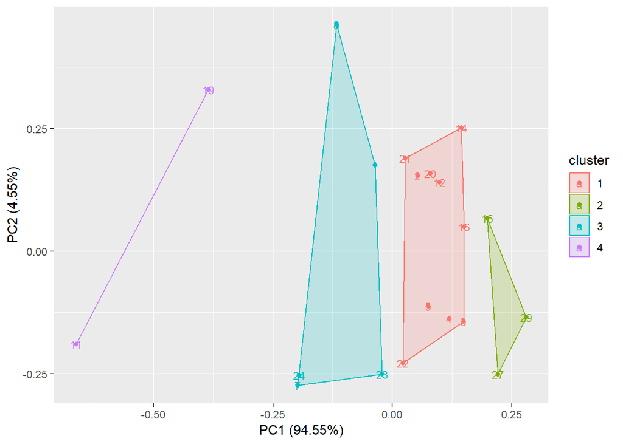

```r
autoplot(segs,data=data5,label = TRUE, label.size = 3, frame = TRUE)
```

## Evaluation

Cette panoplie des avions satisfait seuelement les besoins des distances courte et moyenne distance. Alors que , en comparant cette panoplie avec celle des autres compagnies ,ayant la majorité des avions apartenant à la 4éme catégorie, donc ils couvrent des longues distances. On peut conclure que c’est une panoplie trés modeste.

# Etude de l’age et le nombre d’avions de Tunisair

Exploration du fichier Fleet-Data.csv :

```r
plane<- read.csv("C:/Users/Nidhal/Downloads/Fleet-Data.csv")
plane$ï..Parent.Airline<-NULL
planenum<-plane
planenum$Airline<-NULL
planenum$Aircraft.Type<-NULL
planenum$Unit.Cost<-NULL
planenum$Total.Cost..Current.<-NULL
planenum$Future<-NULL
planenum$Orders<-NULL
planenum<-na.omit(planenum)
planescale<-scale(planenum)
```

Segmentation avec la méthode CAH:

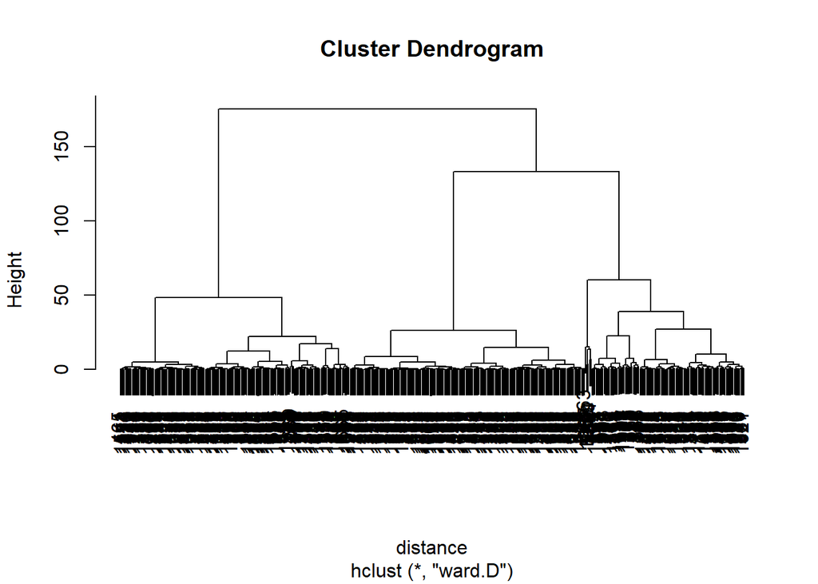

```r
distance<-dist(planescale)
datacah<-hclust(distance,method = "ward.D")
plot(datacah)
```

D’apres le plot, la division de la dataset en 3 segments est la meilleure

resultats de la segmentation

```r
result<-plane
result$Unit.Cost<-NULL
result$Total.Cost..Current.<-NULL
result$Future<-NULL
result$Orders<-NULL
result<-na.omit(result)
result<-cbind(result,datacah)
```

## interpretaion

```r
subset(result, Airline %in% c("Tunisair","Tunisair Express"))
```

```
##               Airline Aircraft.Type Current Historic Total Average.Age
## 1472         Tunisair   Airbus A320      17        3    20        15.7
## 1474 Tunisair Express     ATR 42/72       3        1     4        14.2
## 1476         Tunisair    Boeing 737       7       25    32        16.9
##      datacah
## 1472       1
## 1474       1
## 1476       1
```

On constate que toutes les avions de tunisair sont dans le cluster [1]

```r
subset(result, Airline %in% c("Royal Air Maroc","Royal Air Maroc Express"))
```

```
##                      Airline   Aircraft.Type Current Historic Total
## 1246 Royal Air Maroc Express      ATR 72-600       5        5    10
## 1247         Royal Air Maroc      Boeing 737      37       27    64
## 1248         Royal Air Maroc      Boeing 747       1        3     4
## 1250         Royal Air Maroc      Boeing 767       4        2     6
## 1252         Royal Air Maroc Embraer ERJ-190       4        2     6
##      Average.Age datacah
## 1246         4.5       3
## 1247        10.9       2
## 1248        23.9       1
## 1250        16.0       1
## 1252         2.1       3
```

```r
subset(result, Airline %in% c("EgyptAir"))
```

```
##      Airline Aircraft.Type Current Historic Total Average.Age datacah
## 581 EgyptAir   Airbus A320       6        7    13        17.1       1
## 590 EgyptAir    Boeing 737      22       15    37         7.7       3
## 593 EgyptAir    Boeing 777       9        2    11         9.7       3
```

```r
aggregate(result[,3:7], by=list(datacah),FUN=mean)
```

```
##   Group.1  Current  Historic     Total Average.Age datacah
## 1       1 14.16763 11.907514  26.31792   18.400000       1
## 2       2 78.02500 41.416667 121.07500    9.400833       2
## 3       3 15.66102  6.288136  22.29379    6.618644       3
```

- Cluster [1] : contient les avions qui ont le plus petits nombre d’avions avec l’age moyen le plus eleve
- Cluster [2] : caracterise par le plus nombre d’avion par type et un age moyen de 9ans
- Cluster [3] : contient les modeles d’avions les plus recentes

Toutes les avions de Tunisair appartiennent au cluster [1] , du coup, cette compagnie ne contient que des anciens modéles d’avion. Par contre, les autres compagnies contient des avions plus ou moins recentes.

# Deploiment:

Puisque Tunisair ne répond pas aux exigences internationles , comment peut-elle faire afin de résoudre ce probléme ? Aprés une etude sur l’age des différents modéles d’avion utilisé par Tunisair, on a remarqué que l’age moyen des avions est trop élevé , ce qui va augmenter les maintenances d’une façon plus fréquentes , et peut causer leur disfonctionnement.

Et en faisant une recherche sur les destinations de Tunisair, on a trouvé les résultats suivants: - 13 pays de l’Europe - 8 pays d’Afrique - 7 Pays du Moyen Orient - 1 Pays de l’Amerique du nord.

Alors , on peut remarquer qu’il n’existe pas des vols directes vers des destinations asiatiques. Alors que ces derniers représentent un bon marché à attaquer , grace au population dense mesurant a peu prés 2 Milliards. De meme pour les pays d’afriques, qui sont en train de réaliser une croissance economique énorme, ce qui peut améliorer les chiffres de Tunisair plus rapidement.

Mais, quels sont les besoins pour que Tunisair puisse effectuer cette solution ? Puisque l’economie Tunisienne est en crise , on doit chercher le modéle le moins cher qui peut servir à réaliser la solution proposé.

Aprés une étude sur les caractéristiques des modéles disponibles et en prenant en considération que le chiffre d’affaire de Tunisair qui est trés faible par rapport aux autres compagnies internationales. De meme,les fonds d’investissements à long terme qui sont presque négligeable , on a trouvé qu’on doit le modéle A340 !